# Changes in HDDM parameters depending on sample size used in informing the prior

## T1 HDDM parameters

*Leading question:* Are significant differences in the distributions of the HDDM parameter estimates and their reliabilities depending on whether they are fit on the full sample (n=552) or retest sample (n=150) for t1 data.

### Parameter value

Differences in distributions: using scaled differences

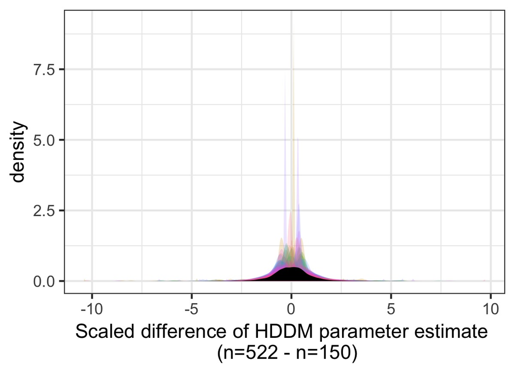

Does the distribution of scaled difference scores (between using n=150 or n=552) have a mean different than 0 allowing for random effects of parameter accounting for the different types of parameters? No.

```r
if(!exists('hddm_pars')){
  source('/Users/zeynepenkavi/Dropbox/PoldrackLab/SRO_DDM_Analyses/code/workspace_scripts/hddm_pars_data.R')
}
summary(lmer(scaled_diff ~ rt_acc + (1|dv), hddm_pars))
```

```
Linear mixed model fit by REML ['lmerMod']
Formula: scaled_diff ~ rt_acc + (1 | dv)
   Data: hddm_pars

REML criterion at convergence: 41695

Scaled residuals:
    Min      1Q  Median      3Q     Max
-10.438  -0.542  -0.004   0.518   9.750

Random effects:
 Groups   Name        Variance Std.Dev.
 dv       (Intercept) 3.24e-33 5.69e-17
 Residual             9.93e-01 9.97e-01
Number of obs: 14722, groups:  dv, 103

Fixed effects:
                    Estimate Std. Error t value
(Intercept)         6.82e-18   9.82e-03       0
rt_accnon-decision -2.70e-17   2.44e-02       0
rt_accthreshold     9.98e-18   2.25e-02       0

Correlation of Fixed Effects:
            (Intr) rt_cc-
rt_ccnn-dcs -0.403
rt_ccthrshl -0.436  0.176
```

```r
# Same result
# summary(MCMCglmm(scaled_diff ~ rt_acc, random = ~ dv, data=hddm_pars))
```

### Parameter reliability

Are there differences in reliability depending which sample the HDDM parameters are estimated from? No.

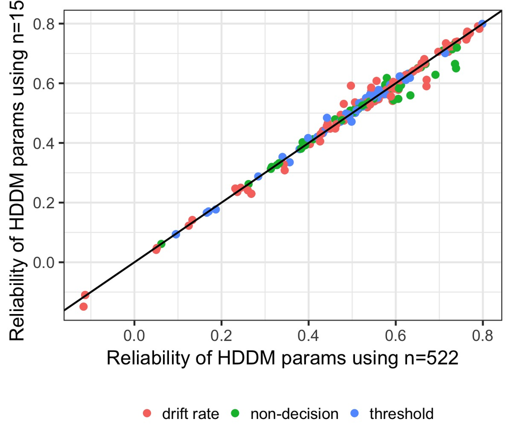

Do hddm parameters differ in their reliability depending on whether they are derived from n=150 or n=552? No.

```r
if(!exists('hddm_rels')){
  source('/Users/zeynepenkavi/Dropbox/PoldrackLab/SRO_DDM_Analyses/code/workspace_scripts/hddm_rel_data.R')}

hddm_rels = hddm_rels %>%
  gather(sample, value, -dv, -rt_acc)

summary(lmer(value ~ sample*rt_acc + (1|dv), hddm_rels))
```

```
Linear mixed model fit by REML ['lmerMod']
Formula: value ~ sample * rt_acc + (1 | dv)
   Data: hddm_rels

REML criterion at convergence: -1207

Scaled residuals:
   Min     1Q Median     3Q    Max
-3.492 -0.260  0.013  0.254  3.510

Random effects:
 Groups   Name        Variance Std.Dev.
 dv       (Intercept) 0.029746 0.172
 Residual             0.000196 0.014
Number of obs: 440, groups:  dv, 220

Fixed effects:
                               Estimate Std. Error t value
(Intercept)                     0.50848    0.01642   30.96
samplerefit                    -0.00331    0.00188   -1.76
rt_accnon-decision              0.03807    0.02889    1.32
rt_accthreshold                -0.02978    0.02836   -1.05
samplerefit:rt_accnon-decision -0.00394    0.00331   -1.19
samplerefit:rt_accthreshold     0.00497    0.00325    1.53

Correlation of Fixed Effects:
            (Intr) smplrf rt_cc- rt_cct smp:_-
samplerefit -0.057
rt_ccnn-dcs -0.568  0.033
rt_ccthrshl -0.579  0.033  0.329
smplrft:r_-  0.033 -0.568 -0.057 -0.019
smplrft:rt_  0.033 -0.579 -0.019 -0.057  0.329
```

### Parameter fit

Do HDDM parameter estimates fit participant data better if the model prior is informed by a larger sample? To assess model fit we sampled parameters from the posterior predictive and generated predicted data (RT distributions) for each subject. Our measure of fit is the KL divergence of the predicted RT distributions from the actual RT distributions from these regressions for each participant.

Here we compare model fits between the same model using a prior using n=552 vs n=150.

*Note:* In calculating the fit statistics for the full sample (n=552) hierarchical models we used fewer samples from the posterior predictive due to computational constraints. We did, however, confirm that the number of samples from the posterior predictive did not have an effect on the fit statistics. Details of those analyses can be found [here](https://zenkavi.github.io/SRO_DDM_Analyses/output/reports/NumSamplesAnalysis.nb.html).

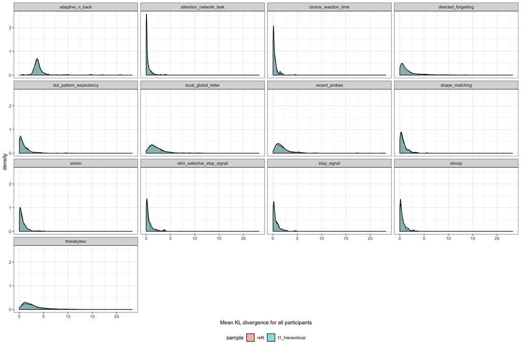

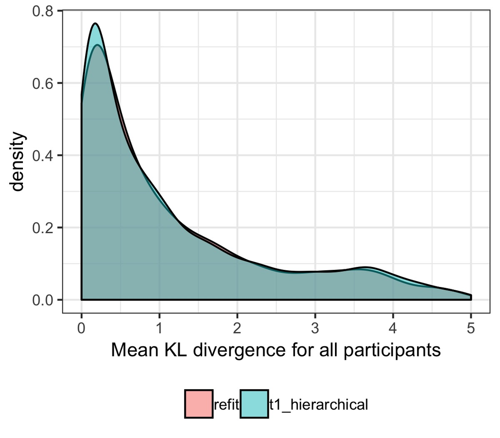

```r
tmp = rbind(refit_fitstats, t1_hierarchical_fitstats)

summary(lm(log(m_kl) ~ sample*task_name, tmp %>% filter(task_name != "motor_selective_stop_signal")))
```

```
Call:
lm(formula = log(m_kl) ~ sample * task_name, data = tmp %>% filter(task_name !=
    "motor_selective_stop_signal"))

Residuals:
   Min     1Q Median     3Q    Max
-3.946 -0.719  0.020  0.755  4.134

Coefficients:
                                                          Estimate
(Intercept)                                                1.35794
samplet1_hierarchical                                     -0.01319
task_nameattention_network_task                           -3.35439
task_namechoice_reaction_time                             -3.02537
task_namedirected_forgetting                              -1.49113
task_namedot_pattern_expectancy                           -2.15009
task_namelocal_global_letter                              -0.89797
task_namerecent_probes                                    -1.01845
task_nameshape_matching                                   -2.16943
task_namesimon                                            -2.28168
task_namestim_selective_stop_signal                       -2.71631
task_namestop_signal                                      -2.54431
task_namestroop                                           -2.60062
task_namethreebytwo                                       -0.70178
samplet1_hierarchical:task_nameattention_network_task      0.14299
samplet1_hierarchical:task_namechoice_reaction_time        0.10496
samplet1_hierarchical:task_namedirected_forgetting         0.02722
samplet1_hierarchical:task_namedot_pattern_expectancy      0.13172
samplet1_hierarchical:task_namelocal_global_letter         0.03974
samplet1_hierarchical:task_namerecent_probes               0.11770
samplet1_hierarchical:task_nameshape_matching              0.10000
samplet1_hierarchical:task_namesimon                      -0.05272
samplet1_hierarchical:task_namestim_selective_stop_signal  0.12190
samplet1_hierarchical:task_namestop_signal                 0.00249
samplet1_hierarchical:task_namestroop                      0.13698
samplet1_hierarchical:task_namethreebytwo                  0.10890
                                                          Std. Error
(Intercept)                                                  0.09174
samplet1_hierarchical                                        0.10409
task_nameattention_network_task                              0.12974
```

[output cut: 68 more lines]

```
samplet1_hierarchical:task_namedot_pattern_expectancy
samplet1_hierarchical:task_namelocal_global_letter
samplet1_hierarchical:task_namerecent_probes
samplet1_hierarchical:task_nameshape_matching
samplet1_hierarchical:task_namesimon
samplet1_hierarchical:task_namestim_selective_stop_signal
samplet1_hierarchical:task_namestop_signal
samplet1_hierarchical:task_namestroop
samplet1_hierarchical:task_namethreebytwo
---
Signif. codes:  0 '***' 0.001 '**' 0.01 '*' 0.05 '.' 0.1 ' ' 1

Residual standard error: 1.12 on 8564 degrees of freedom
Multiple R-squared:  0.422, Adjusted R-squared:  0.42
F-statistic:  250 on 25 and 8564 DF,  p-value: <2e-16
```

*Conclusion:* The fits for tasks differ from each other but the fits using either the full t1 sample (522) or just the retest sample do not differ from each other. For the sake of comparability I chose the refit parameters for the rest of the analyses.